# Planning the next five seconds · nuReasoning Challenge 2026

Planning the next five seconds — Research notes

**Chapters**

**Reading the labels**

**Worked example**

A drawing or arithmetic. Nothing was measured.

**Practice**

Scored by me, on clips whose outcomes were published.

**Official**

Scored by the organizers on outcomes I never saw.

**Not uploaded**

A practice result for a file that missed the deadline.

nuReasoning Challenge 2026 · Competition notes

# Planning the next five seconds

By cheenchan · 24 November 2026

In the 2026 nuReasoning Challenge, Motional and the UCLA Mobility Lab gave teams short recordings from cars fitted with eight cameras. The teams had two jobs. Given the drive so far, where should the car go over the next five seconds? And what could you tell about the traffic around it?

I entered both parts. For the path, I started with the car’s speed and direction. For the questions, I used an existing model that could read the camera views. I kept a simple version of each around while I worked. Both gave me a way to tell whether the next idea was worth putting in a submission.

Chapter 1

## What a team had to submit

For each test clip I received the camera views and a history of the car’s motion. The organizers held back what happened next. I could see complete examples on the practice drives, which meant I could draw a path, score it, and try to understand where it went wrong. [Challenge overview](https://nureasoning-nureasoning-challenge-2026.hf.space/#overview) · [Organizers](https://nureasoning-nureasoning-challenge-2026.hf.space/#organizers) · [How the recordings were chosen](https://motional.com/news/cracking-long-tail-code-autonomous-driving-nureasoning)

**Draw the path · 75% of the score**

Say where the car will be, and which way it will face, every tenth of a second for the next five seconds. Counting the starting point, that makes 51 marks. The organizers score the path from zero to one and call the result the *planning* score.

**Read the scene · 25%**

Choose one lettered answer for each multiple-choice question about the last moment of footage. A question might ask which camera shows a particular vehicle. The share answered correctly is the *reasoning* score.

### A question from the practice set

Rear camera

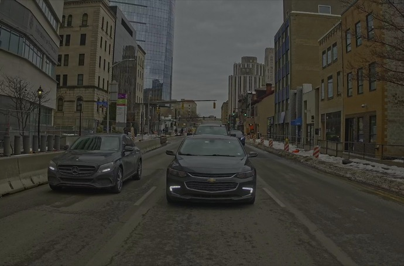

My submission needed 1,000 paths and 3,000 answer letters. A metre of error on a path and a wrong letter are quite different things, so the organizers first gave each task a score between zero and one. With three quarters of the overall score riding on the paths, that was where I started.

Overall = ¾ × planning + ¼ × reasoningAn improvement of 0.01 in planning counts as much as an improvement of 0.03 in reasoning.

Chapter 2

## A planner without cameras

My first planner assumed the car would keep its speed and direction. At 10 metres per second that puts it 50 metres ahead after five seconds. It is a reasonable guess on a straight stretch of road. Give it a car that has just slowed from 12 metres per second to 10, though, and it still draws exactly the same path.

I had the earlier speed readings. I also had practice recordings that showed where the driver actually went. I paired each recent motion history with the path that followed and trained a small network on those pairs. Now a car slowing down and one picking up speed could get different predictions even if they happened to be travelling at the same speed when the clip ended.

### Learning from recent motion beat assuming nothing changes

Practice · 307 clips

Each dot is one planner’s average planning score over the same 307 practice clips. Farther right is better. The axis starts at 0.40, not zero.

Holds speed and direction

**0.5447**Learned from motion

**0.7353**

0.400.500.600.700.80

Learning from recent motion helped enough that I kept this planner around. It also had an obvious blind spot. If a bend was visible up ahead and the driver had yet to steer or brake, nothing in those speed readings would tell it to turn. That was a good case for trying the cameras.

Chapter 3

## Adding cameras made the planner worse

NVIDIA had already trained a driving model, Alpamayo2-Edge, that could take camera images and recent motion and produce a path. I could try it with its weights fixed. I picked 50 practice clips and ran both planners. Edge averaged **0.6277**. My little motion-only network averaged **0.6710** on those very same drives. [NVIDIA’s model card](https://huggingface.co/nvidia/Alpamayo2-Edge)

Before I put time into training Edge, I wanted to know what I had actually shown it. The challenge cameras and the cameras Edge expected didn’t have the same field of view. Resizing an image to the right width and height still leaves a problem. How much of a turn does a given distance across the picture represent?

You can see the problem with a phone camera. Keep a kerb near the edge of the picture and zoom in. The kerb moves across the screen while its direction from where you’re standing stays the same. A driving model that has learned one relationship between pixels and directions will read a different lens incorrectly.

For an ideal camera, the geometry fits on one line. Measure the distance from the centre of the image to the kerb in pixels. Divide by the focal length, also in pixels, to get the tangent of the viewing angle.

tan *θ* = (pixel position − image centre) ÷ focal length*θ* is the angle between the line of sight and straight ahead. Take a kerb that appears 100 pixels from the centre. At focal length 400, tan *θ* = ¼ and the kerb is about 14° off straight ahead. At focal length 200, the same 100 pixels give ½, about 27°.

### Same pixel, different direction

Worked example

Camera’s real focal length200 px

Where the kerb really isWhere a model that assumes focal length 400 puts itAt focal length 200, the kerb is 26.6° off straight ahead. A model that assumes 400 puts it at 14.0°, wrong by 12.5°.

Seen from above. The dot is the same spot in the picture throughout: 100 pixels off-centre. Only the camera’s focal length changes. The numbers 200 and 400 are chosen for easy arithmetic and are not the cameras in the challenge.

I rebuilt each input view one pixel at a time. For a pixel in the camera Edge expected, I worked out which direction it looked and sampled that direction from the challenge image. With the weights fixed, I ran the same 50 clips again.

### Fixing the camera geometry reversed the ranking

Practice · 50 clips

Each dot is one planner’s average planning score over the same 50 practice clips. Farther right is better. The axis starts at 0.60, not zero, which magnifies the gaps.

Edge, pictures as supplied

**0.6277**Motion only

**0.6710**Edge, remapped pictures

**0.7239**

0.600.640.680.720.76

With the pictures as supplied, the planner with cameras trailed motion history by 0.0433. After remapping, it led by 0.0529. The 307-clip comparison in the last chapter used a different set of clips, so compare scores only within one chart.

Now the camera model averaged **0.7239**, ahead of the motion-only planner. I kept the corrected views. This left an interesting choice for the actual entry. Edge can give several different paths for exactly the same drive, and the organizers wanted just one.

Chapter 4

## Choosing one path from six forecasts

Here is one of my practice drives, seen from above. I gave the corrected views to Edge six times. All six predictions go left. Drag the clock through the turn and switch on the recorded path to see where the driver and the model part company.

### Six forecasts for the same left turn

Practice · 1 clip

Seen from above. The car starts at the lower left, facing right. Moving right on the plot means farther ahead. Moving up means farther to the driver’s left.

[figure not shown]

Model forecastsRecorded drive, when revealed

Time ahead5.0 sReveal the driver

Each dot is one forecast at 5.0 seconds.

Same model, same clip, six runs. Nothing about the model or its inputs changed between runs. I chose this practice clip because the turn is easy to see. Each grid square is five metres on a side. Does the recorded path still sit among the forecasts at five seconds?

Five seconds in, the driver is 23.5 metres forward and 13.9 metres to the left of the starting position. Every model path finishes farther left, between 17 and 22 metres. Taking the mean would soften the most extreme guess, but even the mean would turn too far. On other roads, averaging can introduce an error of its own.

### The midpoint can land on the island

Worked example

A drawing seen from above, not a recording. At the marked instant the two dotted circles sit on road. Their midpoint, shown by the cross, lands on the raised island. The dashed centre line is the point-by-point average of the two routes.

The island is a toy example, but the penalty is real. The benchmark scores progress, comfort and resemblance to the recorded driver, then multiplies by factors for collision and road compliance. A path can look smooth all the way to the point where it leaves the road. A zero there costs the score for the entire clip.

*P* = collision factor × road factor × (0.3 × progress + 0.2 × comfort + 0.5 × human similarity)*P* is the planning score for one clip. Think of a path that earns 0.90 inside the parentheses. With both factors equal to one, it keeps 0.90. With a road factor of zero, it earns zero.

The organizers supplied code to grade a path on a practice drive. That gave me a way to learn which paths tended to score well. I made 11 guesses per drive, including the motion-only prediction I had started with, and scored each one. I trained a small model, my *selector*, to predict those grades using only information it would also have on a test drive.

*1*ProposeSix forecasts from Edge, one from the motion-only planner and four blended paths make 11 candidates.

→

*2*Estimate the scoreThe selector learned from the organizers’ own scoring of 1,106 training clips.

→

*3*Choose a pathBlend the two candidates the selector ranks highest. The closer their estimates, the more evenly they are mixed.

How the planner I submitted turned many forecasts into the single path each clip allows. The selector’s safety judgments are estimates, so it can still choose a bad path.

### Was choosing among paths worth it?

Practice · 156 clips

Each dot is an average planning score over the same 156 practice clips. Farther right is better. The axis starts at 0.68, not zero, which magnifies the gaps.

Motion only

**0.6906**One Edge forecast

**0.7317**Average of six

**0.7494**Selector

**0.7632**

0.680.710.740.770.80

Averaging six forecasts gained 0.0177 over a single forecast. Ranking the 11 candidates and blending the top two gained about 0.014 more.

Across 156 practice clips the simple average did quite well. Blending the selector’s top two was a little better, so that was the planner I put in my first entry. I had used those 156 drives to compare several designs by then. They helped me choose a planner, but I gave their scores too much weight when I tried to predict how the entry would do on unfamiliar roads.

Chapter 5

## Reading the scene

For the quiz I went back to the original images. Look again at the car in the yellow box. The question identifies the car with four numbers that locate the box in that particular picture. If I zoom the picture and keep those numbers, I point the model at the wrong patch of street. I gave Edge the original views from two instants and had it score the allowed answer letters.

On my first set of 300 practice questions, the system got 270 right. Then I looked at what I had asked it. I had sampled a lot of questions about traffic cones. Cars appeared much more often in the spatial questions on the test. I could read those questions even though their answers were hidden. I built a broader set of 1,272 questions from 212 practice clips. Plain Edge got 86.08% right there.

A practice question from the opening photograph asks which camera sees a car at the position (−10.1, 0.1) metres. The first number means 10.1 metres behind the recording car. The second puts it just 10 centimetres to one side. That makes the rear view a sensible answer. I added small routines for questions where the supplied positions or camera geometry could help Edge. On my larger practice set the system now scored **88.52%**. I was ready to upload both parts.

Chapter 6

## Three submissions

1. 14 Nov

### First upload: the selector planner and Edge’s answers

   I expected an overall score somewhere between 0.8165 and 0.8258. The server returned **0.7591**. The planner scored 0.7701. The bigger surprise was the quiz, where 88.52% at home had become **72.63%** on the hidden questions. I checked all 3,000 entries for a mix-up between images, questions and answer letters. I found none. At that point I knew my practice set had flattered the system. I didn’t know which kinds of hidden questions it had missed.
2. 15 Nov

### Second upload: more training data for the selector

   I had a second version of the path selector trained with 128 extra clips. Its mean grade on 124 development clips was 0.0042 higher. To see how much that depended on the drives I happened to pick, I repeated the comparison on resampled recordings, keeping clips from each drive together. The middle 95% of those differences ran from −0.0034 to +0.0146. A small loss was plausible. I’d set myself a rule to wait for clearer evidence. I submitted it anyway.

   The quiz stayed at 0.7263. Planning slipped from 0.7701 to 0.7659, and the overall score fell to **0.7560**. The extra data might help on other roads. On these roads I would have done better to keep my first planner.
3. 16 Nov

### Third upload, frovla-xq: same paths, revised answers

   For my third entry I restored the first planner and tried something smaller on the quiz. Remember the car in the rear camera? One practice question gives its position and asks which camera sees it. Another marks it in the image and asks how far away it is. Read separately, the second question asks you to estimate depth from a photograph. Read together, the first gives you a distance you can check against the choices in the second.

   I let the quiz code use positions and boxes supplied in other questions about the same clip alongside Edge’s scores. I used no hand-labelled test answers. The organizers hadn’t given me a specific ruling on using information across questions.

   I compared the two files before submitting. All 1,000 paths matched my first entry and only **76 of the 3,000 letters** had changed. Reasoning rose from 0.7263 to 0.7480. This time I could tell exactly which part of the system had moved the overall score.

¼ × (0.7480 − 0.7263) ≈ **0.0054**The reasoning score rose by 2.17 percentage points. Reasoning carries a quarter of the weight, so the overall score should rise by 0.54 points. It rose from 0.7591 to 0.7645, which is 0.54 points.

### What reached the official leaderboard

Official · hidden outcomes

Each row is one file I uploaded, scored by the organizers against the hidden paths and answers. Overall = ¾ planning + ¼ reasoning, calculated before rounding.

| Upload | Planning | Reasoning | Overall |
| --- | --- | --- | --- |
| 14 Nov · Selector planner, Edge’s answers | 0.7701 | 0.7263 | 0.7591 |
| 15 Nov · More selector training data | 0.7659 | 0.7263 | 0.7560 |
| 16 Nov · First planner, revised answers (frovla-xq) | 0.7701 | 0.7480 | 0.7645 |

My three uploads, by submission date in UTC. The organizers scored each file on the same hidden outcomes. The best overall score, in the highlighted row, set my place on the leaderboard.

**Why I kept Edge for the quiz**

In a separate experiment I trained a smaller model called Qwen. It went from 26 correct answers to 35 on a 60-question check. I might have stopped at that comparison, except that I already had Edge’s answers to the same 60 questions. Edge had 55 right. The training helped Qwen, and I still had good reason to keep the system I had submitted.

Chapter 7

## What I’d take into another challenge

Final result for my best upload, frovla-xqOfficial

**Place**

19th

**Overall**

0.7645

**Planning**

0.7701

**Reasoning**

0.7480

My third entry, **frovla-xq**, finished 19th with 0.7645. I can trace its advantage over my first entry to the revised letters. I have a different kind of evidence for the camera correction. I ran it both ways on 50 practice drives. Only the corrected version went to the server, so I don’t know how much it contributed to the official score. [Official leaderboard](https://nureasoning-nureasoning-challenge-2026.hf.space/#leaderboard)

### The file I never got scored

I prepared a fourth file. I ran the whole planner four times on each clip. When all four endpoints were within three metres of each other, I averaged the paths. Otherwise I kept the original. It was a cheap way to detect disagreement. Paths that diverge around a traffic island and meet again can still fool that rule.

### Which clips benefited from averaging?

Not uploaded · practice, 156 clips

Each square is one of the 156 practice clips, grouped by what averaging did to that clip’s planning score. Colour and pattern show whether the score rose, fell or stayed level.

**60** improved**51** got worse**45** held steady

The average planning score rose from **0.7632 to 0.7722**. Squares count clips, so they don’t show how large each change was. Collision failures fell from eight to six, while failures to stay on the drivable part of the road rose from seven to eight. “Steady” means a change smaller than 10<sup>−8</sup>.

The mean on the 156 practice clips rose from **0.7632 to 0.7722**. In the test file, 861 paths were averaged and 139 stayed as they were. I missed the upload deadline, so the organizers never scored that file. After seeing what happened to the second upload, I wouldn’t use that local gain to estimate where the fourth file might have placed.

### What I’m taking into the next one

If I entered again, I’d still build the little motion-only planner. It earned its keep twice. Its score gave me a reason to inspect my first camera setup, and its predictions later became one of the choices available to the selector.

I’d change when I let myself look at the answers. I’d reserve a set of whole drives before trying any ideas, keep their paths and questions together, and open that set once when the entry was ready. On the camera experiment I could say what I had changed, which drives I had compared, and what had surprised me. I’d like to be able to tell that same simple story about the score I expect before I hit Submit.